# Classification Analysis of Liver Patients Data

Preeti R Dasari

5/22/2019

The aim of this report is to produce classification analysis for liver disease data.

My experience growing up in South of India exposed me to a number of development issues and piqued my interest in aspects of healthcare, education and economics. I found a data set on patients in Andhra Pradesh, my native state, which recorded observations on patients with and without liver disease. Statistical analysis on this kind of dataset might aid towards future diagnoses or preventative treatment for liver diseases. By analyzing the relationship between the variables in this data set, I hope to understand the causes of liver diseases.

The data for liver patients was retrieved from University of California Irvine’s Machine Learning Repository, whose original source was researches in Andhra Pradesh, India.

## Required Packages

```r
require(rpart)
require(graphics)
require(car)
require(dplyr)
require(rpart.plot)
require(gbm)
require(kableExtra)
```

## Importing Data

```r
Liver <- read.csv("Liver.csv"); names(Liver)
```

```
## [1] "Age"      "Gender"   "TB"       "DB"       "Alkphos"  "Proteins"
## [7] "Selector"
```

## Variables in the Dataset

• Age – Age of the Patient in number

• Gender – Gender of the Patient. There are two levels: Female and Male.

• TB – Total Bilirubin

• DB – Direct Bilirubin

• Alkphos – Alkaline Phosphotase

• Total Proteins – protein levels in the body

• Selector – The variable used to differentiate between patients with liver disease and patients without. There are two levels: Yes and No.

## Scatterplot Matrix of Liver Data

I use the function `scatterplotMatrix` from `car` library to show relationships between variables in the liver patient dataset.

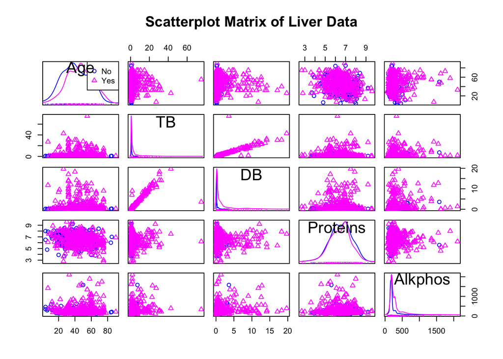

```r
scatterplotMatrix(~Age+TB+DB+Proteins+Alkphos|Selector, data=Liver, smooth=FALSE, regLine=FALSE,ellipse=FALSE, main="Scatterplot Matrix of Liver Data")
```

In this scatterplot matrix, pink data points are people that have a liver disease (Yes) and blue data points are people that don’t have liver disease (No). From an initial study, we can see that people with liver disease tend to have higher Direct Bilirubin levels. Total and Direct Bilirubin share a strong linear relationship, as expected. By looking at the variable distributions, we can read that people that don’t have a liver disease have lower Alkphos, TB and DB levels, and higher Protein levels.

## Classification Analysis

For Classification Analysis, I split the data into training (0.75n) and testing sets (0.25n).

### Splitting Data

```r
set.seed(1)
train = Liver %>%
  sample_n(437)
test = Liver %>%
  setdiff(train)
```

I now use `rpart` to fit a classification model in order to predict Yes using all variables except Selector. I used the `print` function to retrieve information on the model.

```r
tree = rpart(Selector~.-Selector, train)
print(tree)
```

```
## n= 437
##
## node), split, n, loss, yval, (yprob)
##       * denotes terminal node
##
##    1) root 437 122 Yes (0.27917620 0.72082380)
##      2) DB< 0.85 301 114 Yes (0.37873754 0.62126246)
##        4) Alkphos< 212 192  88 Yes (0.45833333 0.54166667)
##          8) Age< 23.5 14   3 No (0.78571429 0.21428571) *
##          9) Age>=23.5 178  77 Yes (0.43258427 0.56741573)
##           18) Alkphos>=152.5 143  67 Yes (0.46853147 0.53146853)
##             36) TB>=1.35 9   2 No (0.77777778 0.22222222) *
##             37) TB< 1.35 134  60 Yes (0.44776119 0.55223881)
##               74) Age< 30.5 22   8 No (0.63636364 0.36363636)
##                148) Alkphos< 184 15   3 No (0.80000000 0.20000000) *
##                149) Alkphos>=184 7   2 Yes (0.28571429 0.71428571) *
##               75) Age>=30.5 112  46 Yes (0.41071429 0.58928571)
##                150) DB>=0.15 93  42 Yes (0.45161290 0.54838710)
##                  300) TB< 0.75 21   5 No (0.76190476 0.23809524) *
##                  301) TB>=0.75 72  26 Yes (0.36111111 0.63888889)
##                    602) Age< 44.5 27  13 Yes (0.48148148 0.51851852)
##                     1204) DB< 0.25 19   7 No (0.63157895 0.36842105) *
##                     1205) DB>=0.25 8   1 Yes (0.12500000 0.87500000) *
##                    603) Age>=44.5 45  13 Yes (0.28888889 0.71111111) *
##                151) DB< 0.15 19   4 Yes (0.21052632 0.78947368) *
##           19) Alkphos< 152.5 35  10 Yes (0.28571429 0.71428571) *
##        5) Alkphos>=212 109  26 Yes (0.23853211 0.76146789) *
##      3) DB>=0.85 136   8 Yes (0.05882353 0.94117647) *
```

The first value in a row is the node. In the first row, this would be 1). The split begins at the root of the tree. At the root, we have 437 observations – these observations were randomly assigned to the training data set when I split my data set 75% - 25%. The number 122 in the first row is loss – which is how many observations are not our yval. Here, my y value is “Yes” (if a patient has a liver disease). This means that in my training data, there are 122 observations that have “No” for the question of whether a patient has liver disease.

The values in the parenthesis indicate the probability of my y value. At the first node (the root), there is 27.92% probability that my y value will not be Yes and a 72.08% probability that my y value will be Yes. I should note that the probability that my y value will not be “Yes” corresponds to the loss proportion of the total observations at that root. (27.92% of 437 is approximately 122).

`Rpart` does not provide a measure of deviance. I manually calculate the value for the first node as an example.

The entropy deviance measure is given by *-2∑<sub>n</sub>∑<sub>k</sub>n<sub>mk</sub>logp<sub>mk</sub>*.

Here, n<sub>10</sub> = 122, n<sub>11</sub> = 315, p<sub>10</sub> = 0.2792, p<sub>11</sub> = 0.7208, where n<sub>10</sub> is the number of observations with “No”, n<sub>11</sub> is the number of observations with “Yes”, p~10 is the corresponding probability for “No” and p<sub>11</sub> is the probability for “Yes”. Since I’m calculating the deviance for the first node, m = 1.

∴ Deviance = -2(*n<sub>10</sub> logp<sub>10</sub>* + *n<sub>11</sub> logp<sub>11</sub>*) = -2(122log(0.2792) + 315log(0.7208)) = 224.77

I would assume that this value would go down as the model splits into more branches and the model becomes more accurate in predicting for my y value.

Finally, I use `rpart.plot` to produce a visual representation of my classification model.

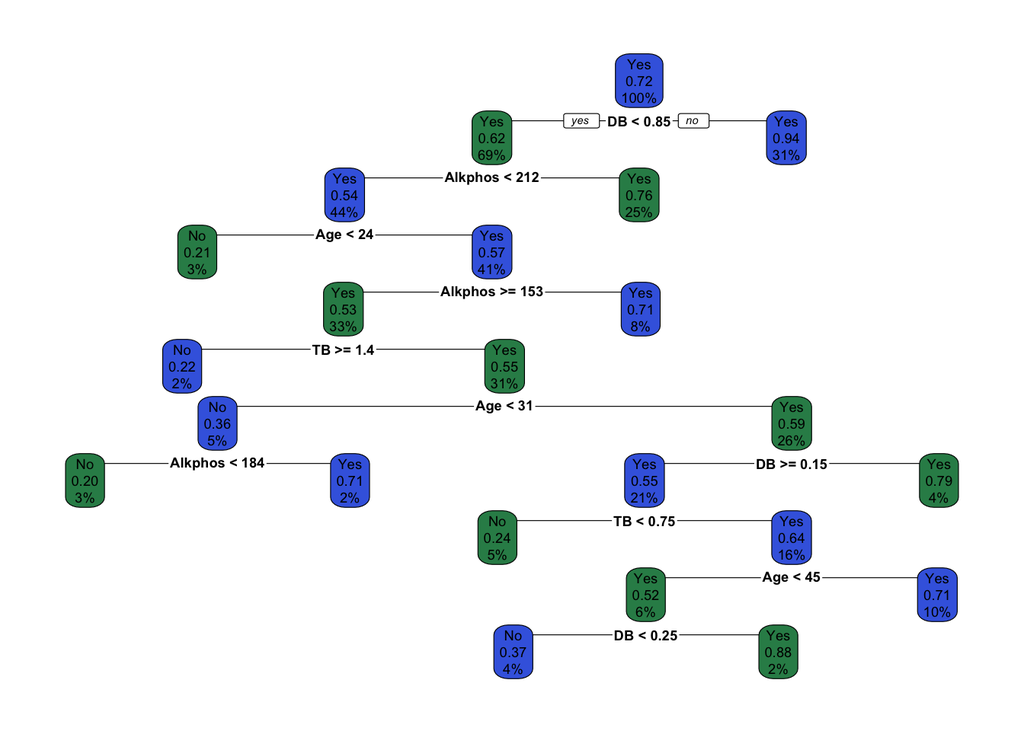

```r
rpart.plot(tree, tweak = 1, fallen.leaves = FALSE, box.col = c("royalblue", "seagreen4"))
```

I now use the `predict` function to see how my model performs on the test data.

```r
tree.preds = predict(tree, test, type="class")
table(tree.preds, test$Selector)
```

```
##
## tree.preds No Yes
##        No  14  14
##        Yes 28  85
```

The classification error rate is (28 + 14)/141 = 29.78%.

One reason the classification tree does not perform better on predicting y values for the test data could be the complexity of the tree, leading to over fitting of the train data. We could create a tree with fewer splits, which would result in reduced complexity and lower variance. However, we might be trading lower variance for higher bias in predicting the probability that a person has a liver disease. Pruning is a process where we begin with a large tree and cut down to an optimal subtree using cross validation and complexity parameter.

## Pruning

`Rpart` automatically provides information for pruning in the summary.

```r
summary(tree)
```

| CP | nsplit | rel_error | xerror | xstd |
| --- | --- | --- | --- | --- |
| 0.0218579 | 0 | 1.0000000 | 1.000000 | 0.0768661 |
| 0.0204918 | 9 | 0.7295082 | 1.114754 | 0.0793327 |
| 0.0100000 | 11 | 0.6885246 | 1.114754 | 0.0793327 |

```r
a=rep(1,583)
a[Liver[,7]=="No"]=0 #creating dummy variable for Selector
a[572:583]
```

```
##  [1] 0 0 0 0 0 0 0 0 0 0 0 0
```

```r
liver = cbind(Liver,a)

set.seed(1)
train.boost = liver %>%
  sample_n(437)
test.boost = liver %>%
  setdiff(train.boost)
```

```r
liver.tree2 = rpart(a~Age+TB+DB+Alkphos+Proteins, train.boost)
bestcp.liver = liver.tree2$cptable[which.min(liver.tree2$cptable[,"xerror"]),"CP"]
pruned.liver = prune(liver.tree2, cp=bestcp.liver)
```

Here, I use **complexity parameter** as my cost function to carry out the cross-validation and pruning process.

```r
prune.liver = predict(pruned.liver, test.boost)
table(prune.liver, test.boost$a)
```

```
##
## prune.liver          0  1
##   0.621262458471761 38 57
##   0.941176470588235  4 42
```

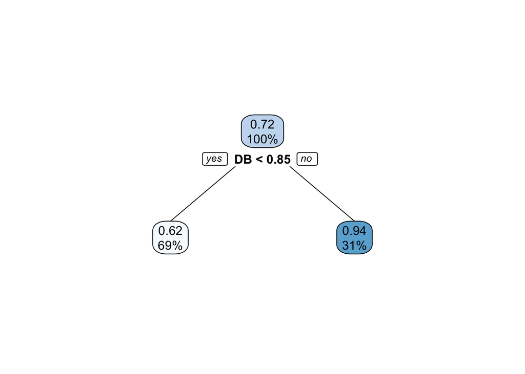

```r
rpart.plot(pruned.liver, fallen.leaves = FALSE)
```

Additionally I produce a visual plot of the pruned tree.

## Boosting

I apply another method - boosting - to improve the prediction model from my classification tree. This method involves creating multiple versions of the training data set and using the versions to build multiple trees. The trees in the boosting process are built on a sequence – each new tree is built by drawing information from the trees that were created previously. This allows the model to learn from previous models and adjust the fit to improve predictions of the y variable.

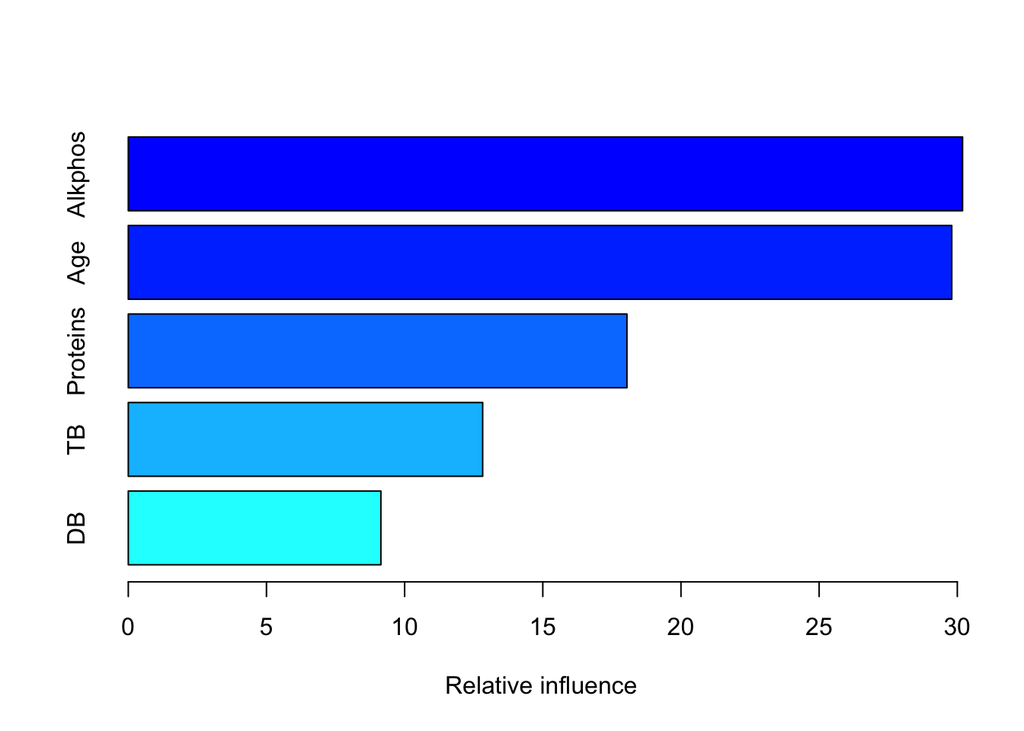

```
##               var   rel.inf
## Alkphos   Alkphos 30.190098
## Age           Age 29.800117
## Proteins Proteins 18.045098
## TB             TB 12.824055
## DB             DB  9.140632
```

```r
set.seed(1)
boost = gbm(a~Age+TB+DB+Alkphos+Proteins, data = train.boost, distribution = "bernoulli", n.trees = 5000, interaction.depth = 5)
boost2 = gbm(a~Age+TB+DB+Alkphos+Proteins, data = train.boost, distribution = "bernoulli", n.trees = 5000, interaction.depth = 5, shrinkage = 0.01, verbose = F)
summary(boost)
```

For my boosting process, I set the number of trees built to 5000; the initial shrinkage parameter λ=0.001, followed by λ=0.01; and my interaction depth as 5.

I use the `summary` function to produce a relative influence plot. Boosting method shows that Alkphos is the most important variable, followed by Age and Proteins. This is different from the output `rpart` produced with its inherent pruning function. In the initial model, Total Bilirubin and Direct Bilirubin were the most important variables.

To further examine the effect of Alkphos (the most important variable in this analysis) on the probability of having a liver disease, I produced a partial dependence plot for the variable.

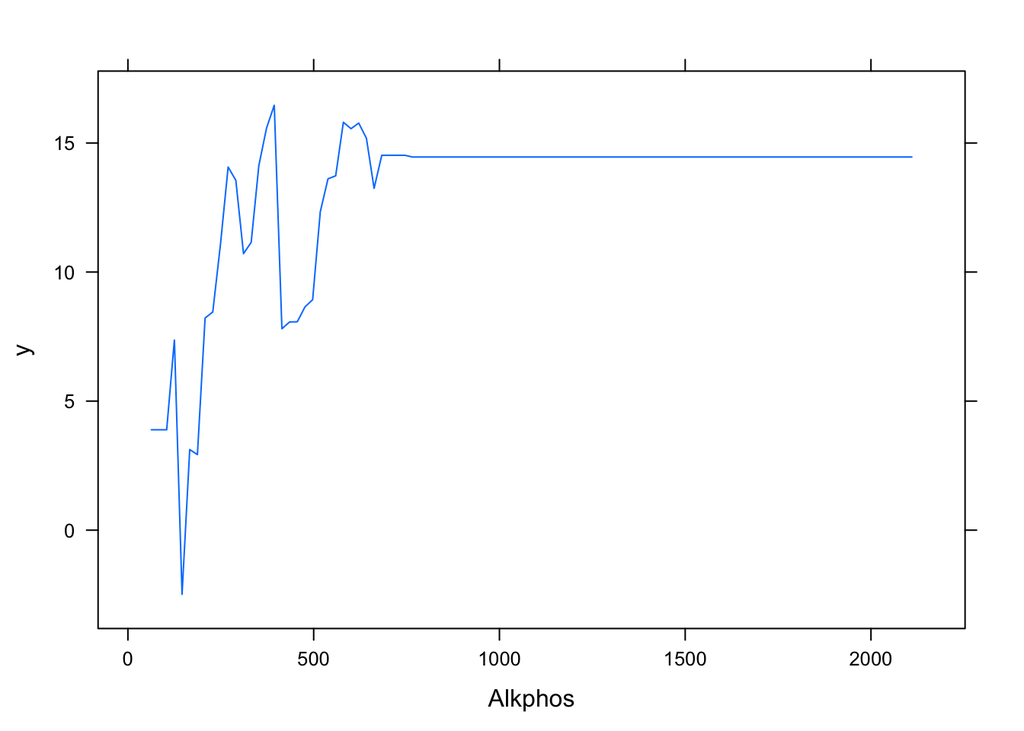

```r
plot(boost,i="Alkphos")
```

Finally, I used the two boosted models to predict **Selector** on the test data.

### Shrinkage Parameter = 0.001

```r
yhat_boost = predict(boost, newdata = test.boost, n.trees = 5000, type = "response")
mean((yhat_boost-test.boost$a)^2)
```

```
## [1] 0.2789284
```

### Shrinkage Parameter = 0.01

```r
yhat_boost2 = predict(boost2, newdata = test.boost, n.trees = 5000)
mean((yhat_boost2-test.boost$a)^2)
```

```
## [1] 8.321868
```